# Executive Summary:

An example output can be found at the end of the summary.

## Background:

Intended for content creators (and their fans), the ability to get understanding of the reaction to a video is mainly through its comments. Unfortunately, the YouTube channel interface does not provide any form of analytics on comments - at present. Additionally, instructional videos and the like depend on accuracy and/or replicability, through which the comments serve as a resource for content improvement and further viewer engagement. Thus, the content creator stands much to gain from the ability to quickly assess the discourse around a video, the negative/positive sentiment of comments, and commonly mentioned topics within.

## Methodology:

The pipeline consists of Youtube API for comments, NLTK for corpus processing, HuggingFace for Sentiment Analysis, YouTubeAPI for transcripts and Matplotlib for results display. It accepts a url or video tag and outputs a graph displaying top # words, top # comments, and the first 140 characters of example comments that contain the first # of the top # words - as well as whether to filter top words/comments by whether or not they contain words used in the video itself. The addition of this transcript-based filter increases the relevancy of the output by selecting only words/comments that directly relate to the video's content.

## Known Limitations:

- **Model Modality**: The model has a single mode: sentiment analysis; it cannot provide in-depth information about the video itself or commonalities between comments beyond word sentiment and frequency. Future improvements may include a summary of all comments of a given sentiment or a summary of the video's content.
- **Model Accuracy**: Top comments and word predictions are limited by the accuracy of the model. Comments containing sarcasm or humor and those with a narrative structure tend to mislead the predictions.
- **English Language Only**: The model has been trained only using English and cannot effectively analyze other languages, though emojis do provide some guidance. In addition, Matplotlib cannot properly display 2-bit characters with default settings.
- **Transcript Filter**: By filtering comments, it is possible that ommissions made during content creation that would have been valuable to results in comments regarding these ommission being overlooked. For example, a travel guide video that didn't visit a certain spot or viewer requests for the next destination. It is likely that the ideal results contain a mix of filtered and non-filtered content. Parenthetically, adding a filter for common English words might improve result relevance.
- **High Freqency Tokens**: Naturally high-frequency, non-stopword tokens distort the output as well, including: "like","see", etc. These could be mitigated by applying an additional filter.

## Conclusion:

This tool, both with and without content filters, can serve to help a content creator get a quick read on the reaction to their video and plan future content, despite sentiment accuracy-related shortcomings.

## Example Output:

The video used for this analysis can be viewed here.

[figure not shown]

# Imports

```python
# Google API imports
from googleapiclient.discovery import build
# using 3rd party MIT license
from youtube_transcript_api import YouTubeTranscriptApi as yta
# ML imports
from transformers import AutoModelForSequenceClassification
from transformers import AutoTokenizer, AutoConfig
from scipy.special import softmax
# operations
import numpy as np
import pandas as pd
import traceback
import os
from collections import Counter
import re
# NLP


# nltk downloads, uncomment if loading from stratch
#import nltk
#nltk.download('punkt_tab')
#nltk.download('stopwords')
from nltk.corpus import stopwords
stop_words = set(stopwords.words("english"))
from nltk.tokenize import word_tokenize
# visualization
import textwrap
import seaborn as sns
import matplotlib.pyplot as plt
%matplotlib inline
```

## Most Frequent 100 words English (via [Oxford English Corpus](https://web.archive.org/web/20111226085859/http://oxforddictionaries.com/words/the-oec-facts-about-the-language))

```python
eng_most_freq = ["the", "be", "to", "of", "and", "a", "in", "that", "have","I","it","for","not","on","with","he","as","you","do","at","this","but","his","by","from","they","we","say","her","she","or","an","will","my","one","all","would","there","their","what","so","up","out","if","about","who","get","which","go","me","when","make","can","like","time","no","just","him","know","take","people","into","year","your","good","some","could","them","see","other","than","then","now","look","only","come","its","over","think","also","back","after","use","two","how","our","work","first","well","way","even","new","want","because","any","these","give","day","most","us"]
pos_most_freq = ["like","great","thank","much","thanks","also","today","good","enjoy","enjoyed","another","hope","said","need","find", "love","try"]
eng_most_freq += pos_most_freq
```

## Load API Key

```python
# load api key
with open("api_key.txt") as file:
    api_key = file.read()
```

# Comment Loader

```python
def get_comments(video_tag,verbose=False,api_key=api_key) -> tuple[pd.DataFrame, str]:
    youtube = build('youtube', 'v3', developerKey=api_key)

    # get title if needed
    video_request=youtube.videos().list(
        part='snippet',
        id=video_tag
        )
    video_response = video_request.execute()
    vid_title = video_response['items'][0]['snippet']['title']

    # get comments
    request = youtube.commentThreads().list(
        part="snippet,replies",
        videoId=video_tag,
        textFormat="plainText"
    )
    # init empty df
    df = pd.DataFrame(columns=['comment','likes'])


    while request:
        comments = []
        likes = []
        try:
            response = request.execute()
            #counter for verbosity
            cycle_count=0

            for item in response['items']:
                # Extracting comments
                comment = item['snippet']['topLevelComment']['snippet']['textDisplay']
                comments.append(comment)
                # Extracting likes
                like_count = item['snippet']['topLevelComment']['snippet']['likeCount']
                likes.append(like_count)

            # create new dataframe
            df2 = pd.DataFrame.from_dict({"comment": comments, "likes":likes},orient="index").transpose()
            # update existing df
            df = pd.concat([df, df2], ignore_index=True)
            # save df just in case
            df.to_json(f"./data/user_comments_{video_tag}.json")
            #get next page
            request = youtube.commentThreads().list_next(request, response)
            #report progress
            if (verbose == True) and (cycle_count % 50 == 0):
                print(f"Iterating. {df.shape[0]} comments detected thus far.")
            cycle_count +=1
        except Exception as e:
            print(f"Reached suspected end-of-page. Exporting to {video_tag}_user_comments.json .")
            df.to_json(f"./data/user_comments_{video_tag}.json")
            print(str(e))
            print(traceback.format_exc())
    return df,vid_title
```

## Load or extract function

```python
# get video comments or load data if cached
def load_video_comments(video_tag) -> tuple[pd.DataFrame,str]:
    # load from cache or request
    comments_path = f"./data/user_comments_{video_tag}.json"
    title_path = f"./data/vid_title_{video_tag}.txt"
    if os.path.exists(comments_path):
        df = pd.read_json(comments_path,encoding="utf-8")
        with open(title_path,"r",encoding="utf-8") as file:
            vid_title = file.read()
    else:
        df,vid_title = get_comments(video_tag)
        with open(title_path,"w",encoding="utf-8") as file:
            file.write(vid_title)
        df.to_json(comments_path)
    return df,vid_title
```

# Load Model

```python
#init model
MODEL = f"cardiffnlp/twitter-roberta-base-sentiment-latest"
tokenizer = AutoTokenizer.from_pretrained(MODEL)
config = AutoConfig.from_pretrained(MODEL)
# PT
model = AutoModelForSequenceClassification.from_pretrained(MODEL)
```

# Preprocessing Helper Functions

```python
#trimming punctuation
def remove_punctuation(text):
    return re.sub(r'[^\w\s]', '', text)
```

```python
# Preprocess text (username and link placeholders)
def preprocess(text:str,remove_nonlexical=False,return_list=True,model_size=514):
    # skip empty / http ->spam
    if (not text) or ("https" in text):
        return ""

    #remove newline and split to list
    if isinstance(text,str):
        # skip blanks and non-Latin
        if not (text[-1].isascii() or text[0].isascii()):
            return ""
        text = text.lower()
        text = text.replace("\n"," ") # remove new line
        # tokenize or just split
        if remove_nonlexical:
            text_as_list = word_tokenize(text)
        else:
            text_as_list = text.split(" ")
    #empty list
    new_text = []
    # for each word in a text
    for t in text_as_list:
        # skip if blank or non-latin
        if (not t or not t[0].isascii()):
            continue
        # anonymization
        t = '@user' if t.startswith('@') and len(t) > 1 else t
        t = 'http' if t.startswith('http') else t

        # lexical processing
        if remove_nonlexical:
            t = remove_punctuation(t) # remove punctuation
            #remove stopwords and blanks
            if (not t or (t in stop_words or t in "nt") or t[-1].isnumeric()):
                continue
        new_text.append(t.lower())
    #limit by model buffer size
    if return_list:
        return " ".join(new_text)[:model_size]
    return new_text
```

# Analyze Sentiments

## Model Forward Statement

```python
# sentiment scores from from str
def process_comment_from_df(raw_text:str) -> tuple[float,float,float]:
    # preprocess text
    text = preprocess(raw_text)
    encoded_input = tokenizer(text, return_tensors='pt')
    # model output
    try:
        output = model(**encoded_input)
        scores = softmax(output[0][0].detach().numpy())

    except Exception as e:
        print("raw text:",raw_text)
        print("processed text:",text)
        print(str(e))
        #print(traceback.format_exc())
        scores = np.zeros(3)

    return list(scores)
```

## Formating Sentiments into Series for DF

```python
# extract sentiments
def sentiment_analysis(df:pd.DataFrame) -> pd.DataFrame:
    senti = df["comment"].map(lambda x: process_comment_from_df(x))
    negative = list(map(lambda x: x[0],senti))
    neutral = list(map(lambda x: x[1],senti))
    positive = list(map(lambda x: x[2],senti))
    senti_df = pd.DataFrame.from_dict({"negative":negative,"neutral":neutral,"positive":positive})
    return pd.concat([senti_df,df],axis=1)
```

## Token Extraction

```python
# add ngrams to df
def build_dictionary(df:pd.DataFrame,return_ngrams=False) -> Counter:
    unigrams_freq = Counter()
    bigrams_freq = Counter()
    bigrams = []
    # TODO: fix bigram generator
    # get tokens
    tokens = df["comment"].map(lambda x: word_tokenize(preprocess(x,remove_nonlexical=True)))
    # get ngrams
    for comment in tokens:
        comment_bigrams = []
        for i in range(len(comment)-1):
            comment_bigrams.append(" ".join(comment[i:i+2]))
        bigrams.append(comment_bigrams)
    # update dictionary
    list(map(lambda x:unigrams_freq.update(x),tokens))
    # update bigrams counter
    list(map(lambda x:bigrams_freq.update(x),bigrams))

    # add columns
    df["unigrams"]=tokens
    df["bigrams"]=bigrams
    if return_ngrams:
        return unigrams_freq,bigrams_freq
```

## Sentiment Pipeline: Comments to Model to DF

```python
# generate sentiment df and top_word_lists
def sentiment_from_df(df,video_tag):
    path_df = f"./data/df_senti_{video_tag}.json"
    if not os.path.exists(path_df):
        df=sentiment_analysis(df)
        build_dictionary(df)
        df_w_senti = df.copy()
        df_w_senti.to_json(path_df)
    else:
        df_w_senti = pd.read_json(path_df)

    return df_w_senti
```

# Get Raw transcript for Filtering

```python
# get English transcript for video
def get_transcript(video_tag,tlang = "en") -> str:
    #open the transcript or make as needed
    if os.path.exists(f"./data/transcript_raw_{video_tag}.txt"):
        with open(f"./data/transcript_raw_{video_tag}.txt","r") as file:
            script_for_output = file.read()
    else:
        transcript = yta.get_transcript(video_tag, languages=[tlang])
        script_concat = ""
        for line in transcript:
            script_concat += " " + line["text"] + " "
        script_for_output = remove_punctuation(script_concat.lower().replace("\n"," "))
        with open(f"./data/transcript_raw_{video_tag}.txt","w",encoding="utf-8") as file:
            file.write(script_for_output)
    return script_for_output
```

# Video Transcript Corpus

```python
# get all words from video transcript
# TODO
def get_set_from_transcript(video_tag,tlang="en"):
    set_path = f"./data/transcript_set_{video_tag}.txt"
    if os.path.exists(set_path):
        with open(set_path, "r") as file:
            transcript_as_str = file.read()
        transcript_set = set([word for word in transcript_as_str.split(" ")])
    else:
        transcript_as_str = get_transcript(video_tag,tlang="en")

        transcript_as_list = [word for word in transcript_as_str.split(" ")]
        # obtain bigrams
        bigrams = []
        for i in range(len(transcript_as_list)-1):
            bigrams.append(" ".join(transcript_as_list[i:i+2]))
        # create set, update with bigrams
        transcript_set = set(transcript_as_list)
        transcript_set.update(bigrams)
        # export to file
        script_for_export = " ".join(transcript_set)
        with open(set_path,"w", encoding="utf-8") as file:
            file.write(script_for_export)
    return transcript_set
```

# Dictionary Building

## Assign sentiment to Tokens, Build dictionary

```python
# get ngram sentiment
def get_ngram_sentiment(df) -> dict:
    # setup vars
    pos_tokens = Counter()
    neg_tokens = Counter()
    for _,row in df.iterrows():
        # check sentiment, make entry
        if (row["negative"] > row["positive"]):
            neg_tokens.update(row["unigrams"])
            neg_tokens.update(row["bigrams"])
        else:
            pos_tokens.update(row["unigrams"])
            pos_tokens.update(row["bigrams"])

    return pos_tokens,neg_tokens
```

## Make/Filter top word lists by sentiment

```python
# return only top words that are more prevealent in dict_a than dict_b
def curate_dicts(word_counter_a:Counter,word_counter_b:Counter,transcript_filter=False):
    result_dict = Counter()
    for word, freq in word_counter_a.items():
        if transcript_filter and word not in transcript_filter:
            continue
        if (word not in eng_most_freq) and (word_counter_b.get(word,0) < freq) and (len(word.replace(" ",""))>2):
            result_dict[word] = freq
    return result_dict.most_common()
```

## Filter dictionaries by video dictionary

```python
# get top N words for each sentiment sentiment
# this is where transcript-based context filters can be applied
def get_top10_words(pos_dict:Counter,neg_dict:Counter,transcript_set:set) -> tuple[Counter]:
    # curate only top most frequent

    pos_top = curate_dicts(pos_dict,neg_dict,transcript_set)
    neg_top = curate_dicts(neg_dict,pos_dict,transcript_set)

    return pos_top, neg_top
```

# Visualizer Pipeline

## Helper Functions Text formating

```python
def format_top_list(top_list:list,max_words:int):
    if isinstance(top_list[0],tuple):
        return [word+f" ({freq})" for (word,freq) in top_list][:max_words]
    else:
        return [word.replace("\n",".")+"..." for word in top_list][:max_words]
```

## Helper Text wrap

```python
# Function to create wrapped text
def wrap_text(text, width=30):
    temp_text = '\n'.join(textwrap.wrap(text, width=width))
    return re.sub(r"( ?•)",r"\n• ",temp_text)
```

```python
def top_list_to_str(word_top,label,max_words):
    temp_str = f"Top {min(max_words,len(word_top))} {label}:\n• "+"\n• ".join(format_top_list(word_top,max_words))
    return temp_str
```

## Get top most frequent tokens from df

```python
def get_top_from_df(df_w_senti,transcript_set=set()):
    # get word,freq dicts by sentiment
    pos_vocab, neg_vocab = get_ngram_sentiment(df_w_senti)
    # get list of top words
    pos_top, neg_top = get_top10_words(pos_vocab, neg_vocab,transcript_set)
    return pos_top,neg_top
```

## Get examples of comments using top frequency tokens

```python
def find_examples_vectorized(df:pd.DataFrame, top_words:list[str],sentiment:str, max_length:int):
    top_com = []
    if sentiment=="Positive":
        df_comments = df[df["positive"]>df["negative"]].sort_values("likes",ascending=False)['comment']
    else:
        df_comments = df[(df["positive"]<df["negative"]) & ((df["neutral"]<df["negative"]))].sort_values("likes",ascending=False)['comment']
    truncated_comments = df_comments.str[:max_length]

    for word, _ in top_words[:5]:
        # Find matches using pandas string operations
        matches = truncated_comments[
            truncated_comments.str.contains(word, na=False) &
            ~truncated_comments.isin(top_com)
        ]
        if not matches.empty:
            top_com.append(matches.iloc[0])
    return top_com
```

```python
def top_list_to_display(df,pos_top,neg_top,max_words=10, max_comments=5,max_com_length=140):
    fig_lower_margin = 11+max_words*.1+max_comments*.1+max_com_length*0.01
    top_list = {}
    top_list["pos_list"] = top_list_to_str(pos_top,f"Positive Words ({len(pos_top)})",max_words)
    top_list["neg_list"] = top_list_to_str(neg_top,f"Negative Words ({len(neg_top)})",max_words)
    pos_com=find_examples_vectorized(df,pos_top,"Positive",max_com_length)
    top_list["pos_com_list"] = top_list_to_str(pos_com,f"Positive Comments",max_comments)
    neg_com=find_examples_vectorized(df,neg_top, "Negative",max_com_length)
    top_list["neg_com_list"] = top_list_to_str(neg_com,f"Negative Comments",max_comments)
    return fig_lower_margin,top_list
```

## Visuals

```python
# visualize comment sentiment
def visualize_sentiments(df,vid_title,fig_height,top_list,video_tag) -> None:
    # set axes, palette
    fg =plt.figure(figsize=(11,fig_height))
    #fg.subplots_adjust(hspace=0.5)
    axd= fg.subplot_mosaic(
        [
            ["kde","kde"],
            ["pos_tokens","neg_tokens"],
            ["pos_comments","neg_comments"],
        ],
    )
    plt.rcParams['font.family'] = 'Segoe UI Emoji'


    # counts
    pos_com_count = df[df["positive"]>df["negative"]].shape[0]
    neg_com_count = df[df["positive"]<df["negative"]].shape[0]
    total_com_count = df.shape[0]
    # title
    fg.suptitle(f"Sentiment Analysis Results: \'{vid_title}\'\n( {total_com_count} Comments: +{pos_com_count/total_com_count:.1%},-{neg_com_count/total_com_count:.1%} )",fontname='Segoe UI Emoji',fontsize=16)
    pal= sns.color_palette("Spectral",n_colors=3, as_cmap=False)

    ## Axis 1: KDE plot
    # plot values
    sns.kdeplot(df[["negative","neutral","positive"]],palette=pal,ax=axd["kde"],fill=True,bw_adjust=0.7,alpha=0.7)
    # adjust lims
    axd["kde"].set_xlim(0.5,1)
    y_lim_tight = axd["kde"].get_ylim()[1] /2
    axd["kde"].set_ylim(0,y_lim_tight)
    axd["kde"].set_facecolor("lightgrey")
    axd["kde"].set_ylabel("Density of Comments")
    axd["kde"].set_xlabel("Sentiment Strength")


    # bbox settings
    fontsize = 12
    bb_dict_pos = dict(facecolor= pal[2], alpha=0.3, boxstyle='round,pad=0.7')
    bb_dict_neg = dict(facecolor= pal[0], alpha=0.3, boxstyle='round,pad=0.7')
    x_offset_pos = -0.1
    ## Axis 2: Top token lists

    # pos words
    axd["pos_tokens"].text(x_offset_pos,0.8,s=top_list["pos_list"],bbox=bb_dict_pos,fontsize=fontsize, verticalalignment="top")
    # neg words
    axd["neg_tokens"].text(0,0.8,s=top_list["neg_list"],bbox=bb_dict_neg,fontsize=fontsize, verticalalignment="top")


    ## Axis 3: Example Comments
    # pos coments display
    axd["pos_comments"].text(x_offset_pos,1,s=wrap_text(top_list["pos_com_list"],55),bbox=bb_dict_pos,fontsize=fontsize, verticalalignment="top",wrap=True)
    # negative comments display
    axd["neg_comments"].text(0,1,s=top_list["neg_com_list"],bbox=bb_dict_neg,fontsize=fontsize, verticalalignment="top",wrap=True)
    # turn off ticks
    axd["pos_tokens"].axis("off")
    axd["neg_tokens"].axis("off")
    axd["pos_comments"].axis("off")
    axd["neg_comments"].axis("off")
    plt.savefig(f"sentiment_display_{video_tag}", bbox_inches="tight")
    plt.show()
```

# Pipeline

```python
# final pipeline for video analysis and visualization
def pipeline(video_tag:str,filter_by_transcript=False,max_words:int=10,max_comments:int=5,max_com_length=140,tlang="en"):
    if video_tag.startswith("http"):
        if "?v=" in video_tag:
            video_tag = video_tag.split("?v=")[1][:11]
        else:
            video_tag = video_tag.split("be/")[1][:11]
    df, vid_title = load_video_comments(video_tag)
    df_w_senti = sentiment_from_df(df,video_tag)
    if filter_by_transcript:
        transcript_set = get_set_from_transcript(video_tag,tlang)
    else:
        transcript_set=set()
    # get top words
    pos_top,neg_top = get_top_from_df(df_w_senti,transcript_set)
    # format tops words for display
    fig_height, top_list = top_list_to_display(df_w_senti,pos_top,neg_top,max_words, max_comments,max_com_length)
    visualize_sentiments(df_w_senti,vid_title,fig_height,top_list,video_tag)
```

# Final Output

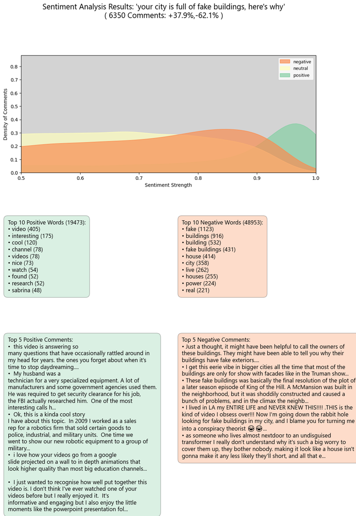

```python
video_tag="https://youtu.be/BeJqgI6rw9k?si=vjrJodS2HMwgvNjW"
pipeline(video_tag,filter_by_transcript=False,max_com_length=250)
```